# Lab Assignment 01 solutions

Jason Pither

This page was last updated on November 18, 2019.

## Load required datasets

```r
titanic <- read.csv(url("https://people.ok.ubc.ca/jpither/datasets/titanic.csv"), header = TRUE)
tiger <- read.csv(url("https://people.ok.ubc.ca/jpither/datasets/tiger.csv"), header = TRUE)
```

## Question 1 (1 mark)

How many variables are in the `titanic` dataframe?

Use `str()` to examine the `titanic` dataframe and determine how many variables it contains.

As shown by the output below, there are 7 variables in the `titanic` dataframe.

```r
str(titanic)
```

```
## 'data.frame':    1313 obs. of  7 variables:
##  $ passenger_class: Factor w/ 3 levels "1st","2nd","3rd": 1 1 1 1 1 1 1 1 1 1 ...
##  $ name           : Factor w/ 1310 levels "Abbing,MrAnthony",..: 22 25 26 27 24 31 45 46 50 54 ...
##  $ age            : num  29 2 30 25 0.917 ...
##  $ embarked       : Factor w/ 3 levels "Cherbourg","Queenstown",..: 3 3 3 3 3 3 3 3 3 1 ...
##  $ destination    : Factor w/ 371 levels "?Havana,Cuba",..: 313 233 233 233 233 240 164 25 23 231 ...
##  $ sex            : Factor w/ 2 levels "female","male": 1 1 2 1 2 2 1 2 1 2 ...
##  $ survive        : Factor w/ 2 levels "no","yes": 2 1 1 1 2 2 2 1 2 1 ...
```

One could also use the `inspect` function, which is **preferred** because it highlights missing values:

```r
inspect(titanic)
```

```
##
## categorical variables:
##              name  class levels    n missing
## 1 passenger_class factor      3 1313       0
## 2            name factor   1310 1313       0
## 3        embarked factor      3  820     493
## 4     destination factor    371  755     558
## 5             sex factor      2 1313       0
## 6         survive factor      2 1313       0
##                                    distribution
## 1 3rd (54.2%), 1st (24.5%), 2nd (21.3%)
## 2 Carlsson,MrFransOlof (0.2%) ...
## 3 Southampton (69.9%), Cherbourg (24.6%) ...
## 4 NewYork,NY (8.6%), London (1.9%) ...
## 5 male (64.7%), female (35.3%)
## 6 no (65.8%), yes (34.2%)
##
## quantitative variables:
##   name   class    min Q1 median Q3 max     mean       sd   n missing
## 1  age numeric 0.1667 21     30 41  71 31.19418 14.74753 633     680
```

Although it’ll do the trick, one should not use the `names` function for this purpose, as you should get into the habit of exploring the structure of the entire data frame at the outset of any project / study. However, marks will **NOT** be deducted this time for using `names`.

## Question 2 (1 mark)

How many categories or “levels” does the `passenger_class` variable have in the `titanic` dataset?

As shown in the `str()` and `inspect` output above, there are three levels in the `passenger_class` variable: 1st, 2nd, and 3rd.

## Question 3 (1 mark)

Calculate the mean and standard deviation for the age of passengers on the titanic.

The mean and standard deviation of the age of passengers is provided by the `inspect` function, as shown above.

It can also be calculated using the `favstats` function:

```r
favstats(~ age, data = titanic)
```

```
##     min Q1 median Q3 max     mean       sd   n missing
##  0.1667 21     30 41  71 31.19418 14.74753 633     680
```

The mean age is 31.2 years and the standard deviation is 14.75 years.

One could also use the `mean` and `sd` functions, ensuring that we take care of missing values:

```r
meanAge <- mean(~ age, data = titanic, na.rm = TRUE)

sdAge <- sd(~ age, data = titanic, na.rm = TRUE)
```

The mean age on the titanic is 31.2 years, with a standard deviation of 14.75 years.

## Question 4 (1 mark)

Calculate the median and IQR for the age of all passengers on the titanic.

The median age of passengers is provided by the `inspect` function or the `favstats` function, as shown above.

The median and IQR can each be calculated using the `median` and `IQR` functions:

```r
medianAge <- median(~ age, data = titanic, na.rm = TRUE)

IQRAge <- IQR(~ age, data = titanic, na.rm = TRUE)
```

The median age on the titanic is 30 years, with an IQR of 20 years.

**NOTE**: It is **not** advisable to calcualate the IQR by hand (Q3 minus Q1) using the values provided by `favstats` or `inspect` functions. You should always have R do any calculations for you, and typically store the result in an object. In future assignments you will lose marks for manual calculations.

## Question 5. (1 mark)

Which measures of centre and spread should be preferred to describe the age of all titanic passengers? Justify your response with the help of an appropriate graph.

Visualize the data with a **histogram**, as this informs us as to which measures of centre and spread are appropriate:

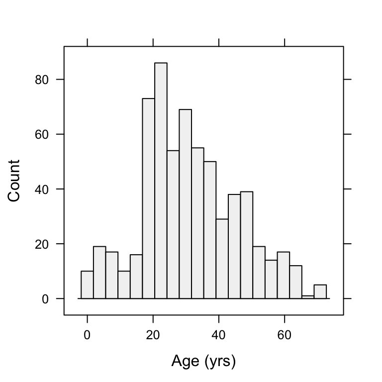

Histogram of passenger ages on the Titanic.

```r
histogram(~ age, data = titanic,
          xlab = "Age (yrs)",
          type = "count",
          nint = 20)
```

Since the passenger age data is asymmetric (Figure 1), the median and IQR are better descriptors of the distribution.

- this distribution is not especially asymmetric (in other words, it is approaching symetrical), so the mean and sd would be acceptable, but median and IQR preferred

## Question 6 (1 mark)

Create a contingency table to display the association between survival and gender (the `survive` and `sex` variables) among passengers of the titanic.

Use the `addmargins()` and `xtabs()` functions to generate a contigency table for survival and sex categories among passengers of the titanic.

```r
addmargins(xtabs(~ survive + sex, data = titanic))
```

```
##        sex
## survive female male  Sum
##     no     156  708  864
##     yes    307  142  449
##     Sum    463  850 1313
```

## Question 7 (1 mark)

Graphically display the association between survival and gender (`survive` and `sex` variables) among passengers of the titanic. Describe what you see.

Because both variables are categorical, we use a grouped bar chart (mosaic plot acceptable) to examine the association between sex and survival among passengers of the titanic.

Here’s a grouped bar chart:

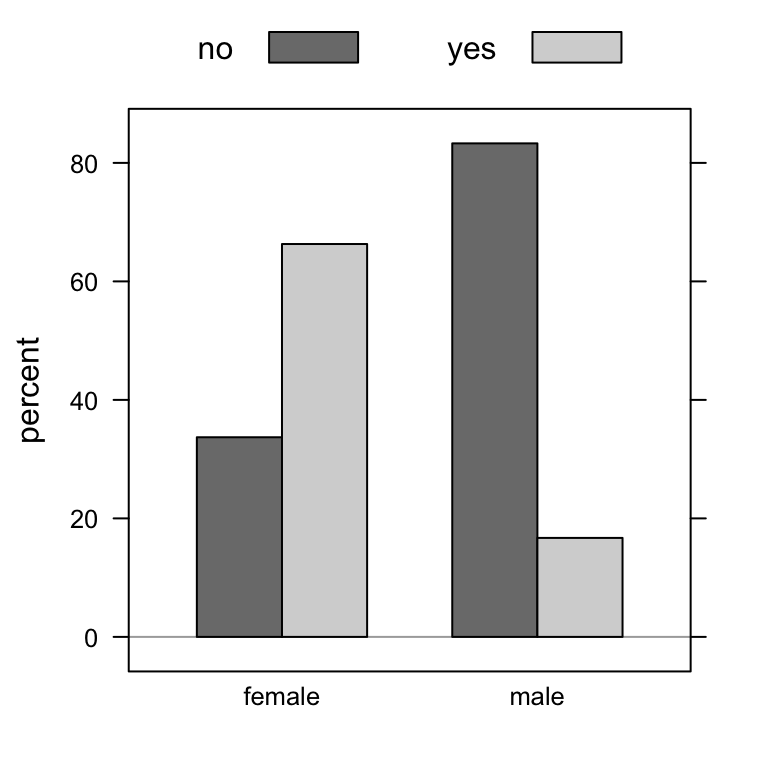

Barplot of male and female passenger survival of the sinking of the Titanic.

```r
barchartGC(~ sex + survive, data = titanic, type = "perc")
```

And a mosaic plot:

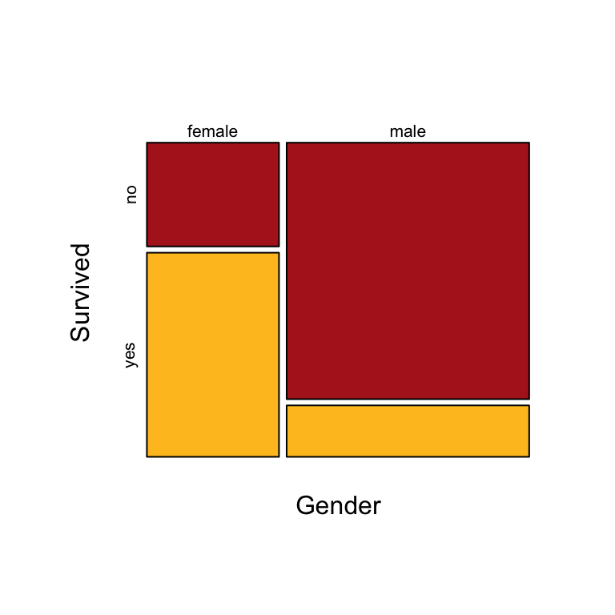

Mosaic plot of male and female passenger survival of the sinking of the Titanic.

```r
mosaicplot(xtabs(~ sex + survive, data = titanic),
           col = c("firebrick", "goldenrod1"),
           xlab = "Gender",
           ylab = "Survived",
           main = "") # don't show main title because we have a proper figure caption
```

Proportionally, more female passengers survived the sinking of the titanic than did male passengers (Figures 2 and 3). Roughly 35% of female passengers and over 80% of male passengers died.

## Question 8. (1 mark)

Graphically display the association between `age` and `passenger_class` among titanic passengers. Justify your choice of graph type. Describe what you see.

First, look at how many observations are in each group using `xtabs()` (or also the `table` function in the base R package would work):

```r
xtabs(~ passenger_class, data = titanic)
```

```
## passenger_class
## 1st 2nd 3rd
## 322 280 711
```

There are >> 20 observations in each group, so use `boxplot()` to create a boxplot.

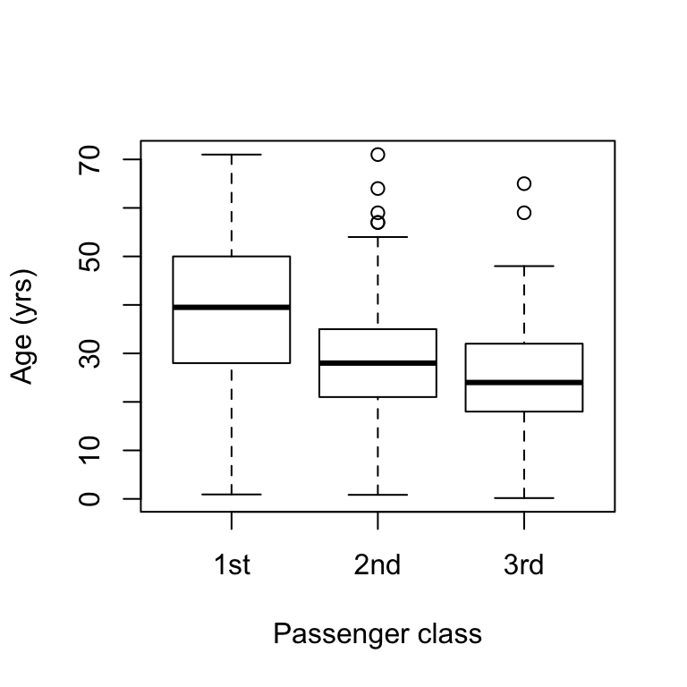

Boxplot of passenger age distribution per passenger class on the Titanic.

```r
boxplot(age ~ passenger_class, data = titanic,
        ylab = "Age (yrs)",
        xlab = "Passenger class")
```

The median age of 1st class passengers was higher than the median age for both 2nd and 3rd class passengers (Figure 4). The interquartile range for 1st class passengers was also larger than for either 2nd or 3rd class passengers.

## Question 9 (1 mark)

Calculate the mean and standard deviation of age for passengers in each category of `passenger_class`.

`favstats()` can calculate descriptive statistics for associations between variables. Use that function to return all the needed statistics for the associations between passenger class and age.

```r
ageClass <- favstats(age ~ passenger_class, data = titanic)
ageClass
```

```
##   passenger_class    min Q1 median Q3 max     mean       sd   n missing
## 1             1st 0.9167 28   39.5 50  71 39.66777 14.93044 226      96
## 2             2nd 0.8333 21   28.0 35  71 28.30031 13.00764 212      68
## 3             3rd 0.1667 18   24.0 32  65 24.51966 11.33059 195     516
```

- not advisable to use the `mean` and `sd` functions, because one needs to subset and use the `na.rm = TRUE` argument

## Question 10 (1 mark)

Graphically display the frequency distribution of the `activity` variable in the `tiger` dataset. Describe what you see.

First, look at the data structure in the `tiger` dataset, using either `str` or `inspect`.

```r
str(tiger)
```

```
## 'data.frame':    88 obs. of  2 variables:
##  $ person  : int  1 2 3 4 5 6 7 8 9 10 ...
##  $ activity: Factor w/ 9 levels "Disturbing tiger kill",..: 1 3 5 4 5 3 5 2 4 5 ...
```

Since it is a factor (categorical) variable, a barchart is the appropriate graph. However, the data must be sorted before it is displayed.

1. Create a frequency table with `xtabs()`
2. Sort the frequency table with `sort()`

```r
actFreq <- xtabs(~ activity, data = tiger)

actFreqSort <- sort(actFreq, decreasing = FALSE)
```

use the `barchartGC()` function to display the new dataframe. Activity names are long, so display horizontally.

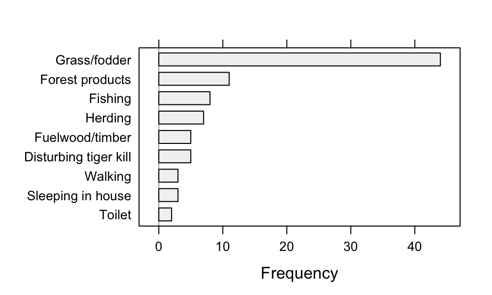

Frequency distribution of activities in the tiger dataset.

```r
barchartGC(actFreqSort, horizontal = TRUE, xlab = "Frequency")
```

The “Grass/fodder” was by far the most frequent activity in the tiger dataset (Figure 5); there were over 40 observations of this activity. All other categories had frequencies less than 15, and the “Walking,” “Sleeping in house,” and “Toilet” activities each had frequencies less than 5.